# Store Deliveries

Next, scatterplots are created of *Actual_Delivery_Time vs. Predicted_Delivery Time*. Ideally, the predicted delivery time should be equal to or greater than the actual delivery time to appropriately manage customer expectations (i.e. a customer would likely be less frustrated if the actual delivery time was equal to or less than the expected delivery time, compared to the opposite scenario).

The last two plots are for calibrated predicted delivery times (second of these plots is faceted by *Weekend* and *Time_of_Day*). To calibrate, correction factors were applied to predicted delivery times (post-model prediction) to ensure that they mostly exceeded the actual delivery times. I experimented with the calibration, and found that to achieve this goal, the uncalibrated predicted delivery times should be multiplied by 1.2 and then 10 should be added. For example, if the model predicted a delivery time to be 40 minutes, the calibrated delivery time would be (40 x 1.2) + 10 = 58 minutes.

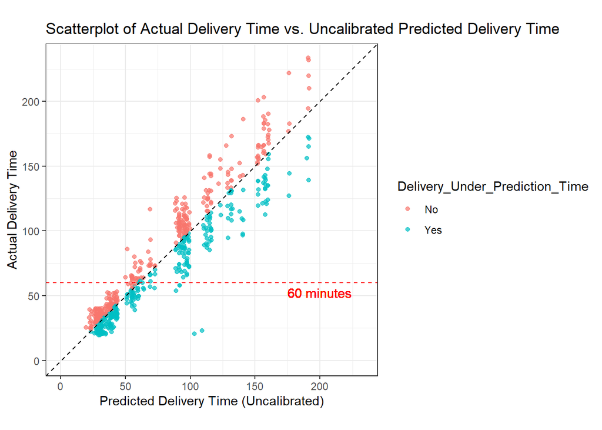

```r
df_pred <- data_val %>%
                 mutate(Predicted_Delivery_Time=preds) %>%
                 rename(Actual_Delivery_Time=Delivery_Time) %>%
                 mutate(Delivery_Under_Prediction_Time =
                    ifelse(Predicted_Delivery_Time > Actual_Delivery_Time,"Yes","No"))

df_pred %>% ggplot(., aes(x=Predicted_Delivery_Time, y=Actual_Delivery_Time,
                          color=Delivery_Under_Prediction_Time)) +
                        geom_jitter(alpha=0.7) +
                        geom_abline(intercept = 0, slope=1,
                                    linetype="dashed", size=0.5) +
                        geom_hline(yintercept=60, linetype="dashed", color = "red", size=0.5) +
                        coord_fixed(ratio=1, xlim=c(0, max(df_pred$Actual_Delivery_Time)),
                                    ylim=c(0, max(df_pred$Actual_Delivery_Time))) +
                        theme_bw() +
                        labs(x="Predicted Delivery Time (Uncalibrated)", y="Actual Delivery Time") +
                        geom_text(aes(x=200, label="60 minutes", y=60), colour="red",vjust = 1.5) +
                        ggtitle("Scatterplot of Actual Delivery Time vs. Uncalibrated Predicted Delivery Time")
```

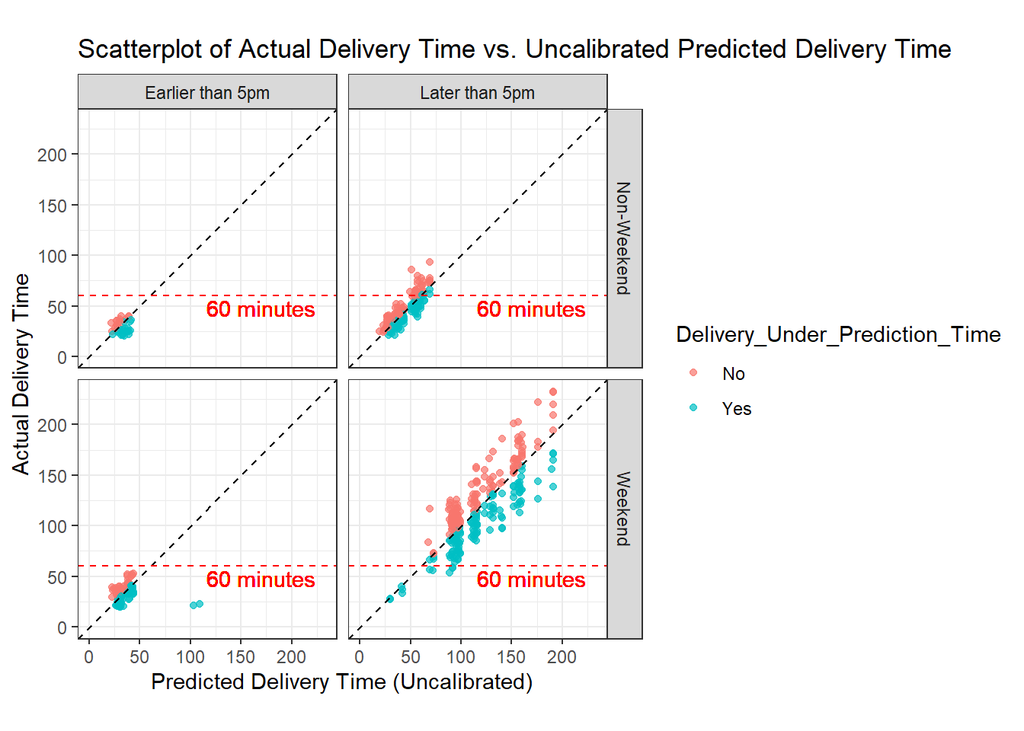

```r
df_pred %>% ggplot(., aes(x=Predicted_Delivery_Time, y=Actual_Delivery_Time,
                          color=Delivery_Under_Prediction_Time)) +
                        geom_jitter(alpha=0.7) +
                        geom_abline(intercept = 0, slope=1,
                                    linetype="dashed", size=0.5) +
                        geom_hline(yintercept=60, linetype="dashed", color = "red", size=0.5) +
                        coord_fixed(ratio=1, xlim=c(0, max(df_pred$Actual_Delivery_Time)),
                                    ylim=c(0, max(df_pred$Actual_Delivery_Time))) +
                        theme_bw() +
                        labs(x="Predicted Delivery Time (Uncalibrated)", y="Actual Delivery Time") +
                        geom_text(aes(x=170, label="60 minutes", y=65), colour="red",vjust = 1.5) +
                        facet_grid(rows = vars(Weekend), cols=vars(Time_of_Day)) +
                        ggtitle("Scatterplot of Actual Delivery Time vs. Uncalibrated Predicted Delivery Time")
```

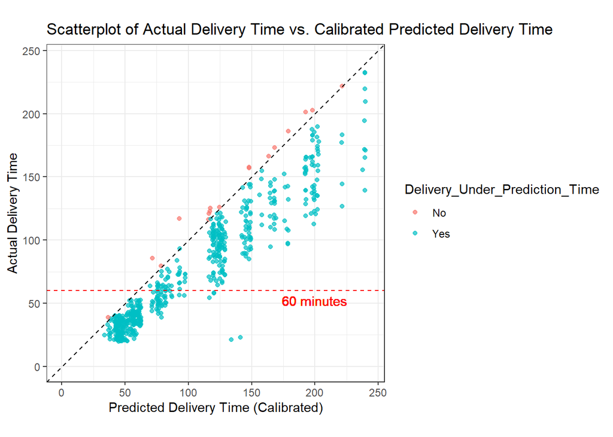

```r
Calibrate_int=10
Calibrate_slope=1.2

df_pred <- df_pred %>%
               mutate(Predicted_Delivery_Time=Predicted_Delivery_Time*Calibrate_slope+Calibrate_int) %>%
               mutate(Delivery_Under_Prediction_Time=
                  ifelse(Predicted_Delivery_Time > Actual_Delivery_Time,"Yes","No"))

df_pred %>% ggplot(., aes(x=Predicted_Delivery_Time, y=Actual_Delivery_Time,
                          color=Delivery_Under_Prediction_Time)) +
                        geom_jitter(alpha=0.7) +
                        geom_abline(intercept = 0, slope=1,
                                    linetype="dashed", size=0.5) +
                        geom_hline(yintercept=60, linetype="dashed", color = "red", size=0.5) +
                        coord_fixed(ratio=1, xlim=c(0, max(df_pred$Actual_Delivery_Time)+Calibrate_int),
                                    ylim=c(0, max(df_pred$Actual_Delivery_Time)+Calibrate_int)) +
                        theme_bw() +
                        labs(x="Predicted Delivery Time (Calibrated)", y="Actual Delivery Time") +
                        geom_text(aes(x=200, label="60 minutes", y=60), colour="red",vjust = 1.5) +
                        ggtitle("Scatterplot of Actual Delivery Time vs. Calibrated Predicted Delivery Time")
```

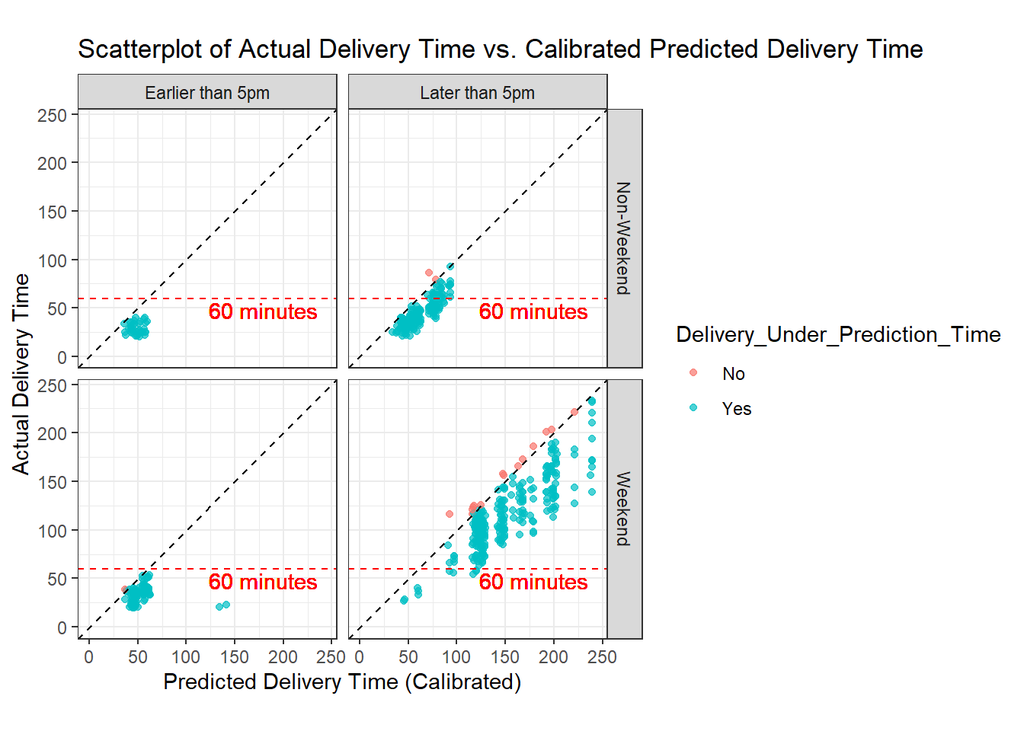

```r
df_pred %>% ggplot(., aes(x=Predicted_Delivery_Time, y=Actual_Delivery_Time,
                          color=Delivery_Under_Prediction_Time)) +
                        geom_jitter(alpha=0.7) +
                        geom_abline(intercept = 0, slope=1,
                                    linetype="dashed", size=0.5) +
                        geom_hline(yintercept=60, linetype="dashed", color = "red", size=0.5) +
                        coord_fixed(ratio=1, xlim=c(0, max(df_pred$Actual_Delivery_Time)+Calibrate_int),
                                    ylim=c(0, max(df_pred$Actual_Delivery_Time)+Calibrate_int)) +
                        theme_bw() +
                        labs(x="Predicted Delivery Time (Calibrated)", y="Actual Delivery Time") +
                        geom_text(aes(x=180, label="60 minutes", y=65), colour="red",vjust = 1.5) +
                        facet_grid(rows = vars(Weekend), cols=vars(Time_of_Day)) +
                        ggtitle("Scatterplot of Actual Delivery Time vs. Calibrated Predicted Delivery Time")
```

## 5) Conclusions

Utilizing the model to predict delivery times and then calibrating them allows for the vast majority of predicted delivery times to exceed the actual delivery times. As previously stated, this situation is ideal as customers will likely be more satisfied if they get deliveries sooner than expected. Though this is not a permanent solution to the problem of reducing delivery times, it is a great temporary solution while the company sorts out other mechanisms to decrease voids and reduce delivery times.